# Machine Learning Assignment: Exercise Manner Prediction

EParc

July 13, 2018

# Executive summary

In this final assignment of the course module on Machine Learning offered by the Johns Hopkins University on coursera. The goal of the assignment is to predict the manner in which the exercise was performed. The data was collected by using devices such as Jawbone Up, Nike FuelBand, and Fitbit. Finally the prediction model was used to predict 20 different test cases.

# Tidy data

The provided raw training and test data is loaded. Whereafter the data is cleaned. Both sets are checked on NA values and variance. Only when there are no NA values a variable is accepted. Also a variance test is performed. There must be variance in a variable to be accepted.

```r
library(caret)
library(rpart)
library(randomForest)
library(rattle)
```

```r
# Loading data
test_data <- read.csv("~/pml-testing.csv", header = TRUE, sep = ",", na.strings = c("NA", "#DIV/0!", ""))
train_data <- read.csv("~/pml-training.csv", header = TRUE, sep = ",",  na.strings = c("NA", "#DIV/0!", ""))

# Select Columns with good data (data with variance)
NZV <- nearZeroVar(train_data)
train_data <- train_data [, -NZV]
NZV <- nearZeroVar(test_data)
test_data <- test_data [, -NZV]
train_data <- train_data[, -c(1:7)]
test_data <- test_data[, -c(1:7)]

# Select variables with no NA's
test_data <- test_data[complete.cases(test_data), ]
sel_cols <- c(colnames(test_data), "classe")
train_data <- train_data[,colnames(train_data) %in% sel_cols]
```

# Exploratory data analysis

A quick analysis on the probability was performed

```r
# Check the probability of the variable classe
prop.table(table(train_data$classe))
```

```
##
##         A         B         C         D         E
## 0.2843747 0.1935073 0.1743961 0.1638977 0.1838243
```

# Cross Validation

For cross validation a partition (70/30) within the training dataset is created

```r
inTrain  <- createDataPartition(train_data$classe, p=0.7, list=FALSE)
Train_Set <- train_data[inTrain, ]
Train_TestSet  <- train_data[-inTrain, ]
```

# Random Forrest

A Random Forrest model is trained on the training set

```r
set.seed(98765)
Forest <- trainControl(method="cv", number=3, verboseIter=FALSE)
Fitting_model_RF <- train(classe ~ ., data=Train_Set, method="rf", trControl=Forest, na.action=na.roughfix)
Fitting_model_RF$finalModel
```

```
##
## Call:
##  randomForest(x = x, y = y, mtry = param$mtry)
##                Type of random forest: classification
##                      Number of trees: 500
## No. of variables tried at each split: 26
##
##         OOB estimate of  error rate: 0.74%
## Confusion matrix:
##      A    B    C    D    E class.error
## A 3902    4    0    0    0 0.001024066
## B   24 2624    8    0    2 0.012791573
## C    0   16 2371    8    1 0.010434057
## D    0    0   22 2226    4 0.011545293
## E    0    0    5    7 2513 0.004752475
```

# Model Evaluation

To evaluate the Random Forests model we need to use it for making predictions on the training set and the testing set. See Appendix 1 for the Decision Tree.

```r
predict_RForest <- predict(Fitting_model_RF, newdata=Train_TestSet, na.action = na.pass)
conf_Mat_RForest <- confusionMatrix(predict_RForest, Train_TestSet$classe)
conf_Mat_RForest
```

```
## Confusion Matrix and Statistics
##
##           Reference
## Prediction    A    B    C    D    E
##          A 1672    8    0    0    0
##          B    1 1129    9    0    0
##          C    0    2 1010   13    0
##          D    0    0    7  951    3
##          E    1    0    0    0 1079
##
## Overall Statistics
##
##                Accuracy : 0.9925
##                  95% CI : (0.99, 0.9946)
##     No Information Rate : 0.2845
##     P-Value [Acc > NIR] : < 2.2e-16
##
##                   Kappa : 0.9905
##  Mcnemar's Test P-Value : NA
##
## Statistics by Class:
##
##                      Class: A Class: B Class: C Class: D Class: E
## Sensitivity            0.9988   0.9912   0.9844   0.9865   0.9972
## Specificity            0.9981   0.9979   0.9969   0.9980   0.9998
## Pos Pred Value         0.9952   0.9912   0.9854   0.9896   0.9991
## Neg Pred Value         0.9995   0.9979   0.9967   0.9974   0.9994
## Prevalence             0.2845   0.1935   0.1743   0.1638   0.1839
## Detection Rate         0.2841   0.1918   0.1716   0.1616   0.1833
## Detection Prevalence   0.2855   0.1935   0.1742   0.1633   0.1835
## Balanced Accuracy      0.9985   0.9946   0.9907   0.9922   0.9985
```

# Out of Sample Error

The out of sample error was calculated by 1 minus the accuracy

```r
1 - Fitting_model_RF$results[2,2]
```

```
## [1] 0.01142899
```

# Prediction

Now we use this Random Forests model to predict the dedicated testing set (only 20 evaluations) for the submission part of the course project:

```r
Final_Prediction <- predict(Fitting_model_RF, newdata=test_data)
Final_Prediction
```

```
##  [1] B A B A A E D B A A B C B A E E A B B B
## Levels: A B C D E
```

# Appendices

## Appendix 1: Decision Tree

[figure not shown]

```r
Dec_Tree_Mod_Fit <- rpart(classe ~ ., data=Train_Set, method="class")
fancyRpartPlot(Dec_Tree_Mod_Fit, cex = 0.3)
```

## Appendix 2: Decision Tree - Accuracy

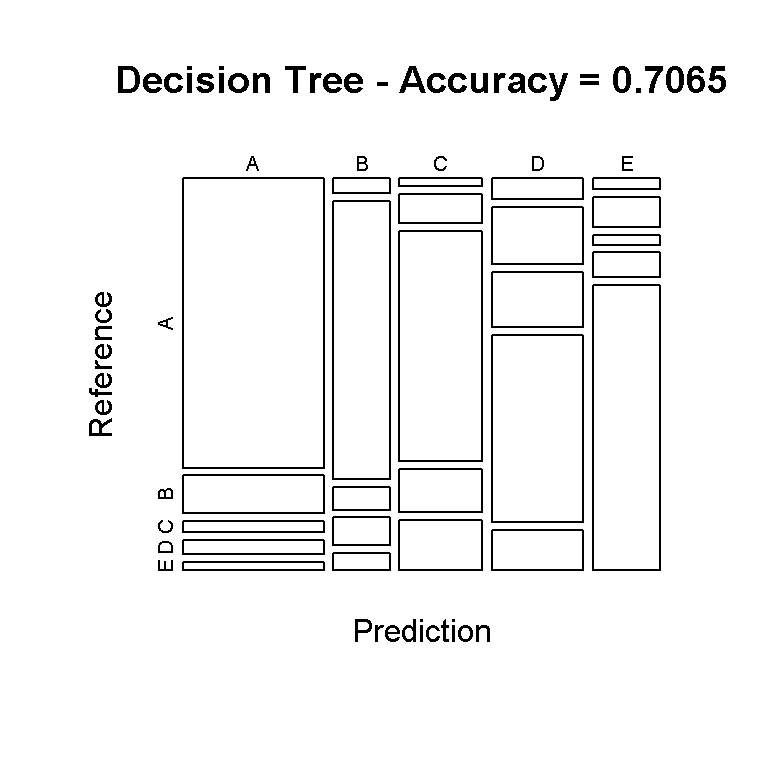

```r
Predict_Dec_Tree <- predict(Dec_Tree_Mod_Fit, newdata=Train_TestSet, type="class")
conf_Mat_Dec_Tree <- confusionMatrix(Predict_Dec_Tree, Train_TestSet$classe)
plot(conf_Mat_Dec_Tree$table, col = conf_Mat_Dec_Tree$byClass, main = paste("Decision Tree - Accuracy =", round(conf_Mat_Dec_Tree$overall['Accuracy'], 4)))
```

# References

Many thanks to http://web.archive.org/web/20161224072740/http:/groupware.les.inf.puc-rio.br/har for making the dataset available for the Coursera Course. Ugulino, W.; Cardador, D.; Vega, K.; Velloso, E.; Milidiu, R.; Fuks, H. Wearable Computing: Accelerometers’ Data Classification of Body Postures and Movements